# TP 6 : Texte et expressions régulières

Rémi Pierron

2026-11-19

Dépôt GitHub : https://github.com/remipierron/TP6_R

# Partie A : Fonctions de texte et premières regex

## A1

### Prédictions (écrites avant l’exécution)

| Instruction | Prédiction |
| --- | --- |
| `nchar("Été 2026 ")` | `9` : « Été » (3), l’espace, « 2026 » (4) et l’espace final ; le « É » accentué compte pour **un** caractère. |
| `str_sub("Conservatoire", -5)` | `"toire"` : un indice négatif part de la fin, on garde les 5 derniers caractères. |
| `str_detect(c("a.b", "axb", "ab"), "a.b")` | `TRUE TRUE FALSE` : le `.` est un métacaractère qui remplace **n’importe quel** caractère, mais il en faut exactement un entre `a` et `b`. |
| `str_detect(c("a.b", "axb", "ab"), "a\\.b")` | `TRUE FALSE FALSE` : `\\.` désigne un point littéral. |
| `str_count("banana", "an")` | `2` : « b**anan**a ». |
| `str_replace("aaa", "a", "b")` | `"baa"` : `str_replace()` ne remplace que la **première** occurrence. |
| `str_extract("Tel : 06 12 34 56 78", "\\d+")` | `"06"` : première suite de chiffres, qui s’arrête au premier espace. |
| `str_split("a,b,,c", ",")` | une **liste** contenant `c("a", "b", "", "c")` : les deux virgules consécutives produisent une chaîne vide. |

### Exécution

```r
nchar("Été 2026 ")
```

```
## [1] 9
```

```r
str_sub("Conservatoire", -5)
```

```
## [1] "toire"
```

```r
str_detect(c("a.b", "axb", "ab"), "a.b")
```

```
## [1]  TRUE  TRUE FALSE
```

```r
str_detect(c("a.b", "axb", "ab"), "a\\.b")
```

```
## [1]  TRUE FALSE FALSE
```

```r
str_count("banana", "an")
```

```
## [1] 2
```

```r
str_replace("aaa", "a", "b")
```

```
## [1] "baa"
```

```r
str_extract("Tel : 06 12 34 56 78", "\\d+")
```

```
## [1] "06"
```

```r
str_split("a,b,,c", ",")
```

```
## [[1]]
## [1] "a" "b" ""  "c"
```

Pour comparer sans recopier les résultats à la main, on range les prédictions et les résultats dans deux listes, puis on les compare une à une avec `identical()` :

```r
predictions <- list(
  nchar       = 9L,
  str_sub     = "toire",
  detect_1    = c(TRUE, TRUE, FALSE),
  detect_2    = c(TRUE, FALSE, FALSE),
  str_count   = 2L,
  str_replace = "baa",
  str_extract = "06",
  str_split   = list(c("a", "b", "", "c"))
)
resultats <- list(
  nchar       = nchar("Été 2026 "),
  str_sub     = str_sub("Conservatoire", -5),
  detect_1    = str_detect(c("a.b", "axb", "ab"), "a.b"),
  detect_2    = str_detect(c("a.b", "axb", "ab"), "a\\.b"),
  str_count   = str_count("banana", "an"),
  str_replace = str_replace("aaa", "a", "b"),
  str_extract = str_extract("Tel : 06 12 34 56 78", "\\d+"),
  str_split   = str_split("a,b,,c", ",")
)
prediction_juste <- map2_lgl(predictions, resultats, identical)
prediction_juste
```

```
##       nchar     str_sub    detect_1    detect_2   str_count str_replace
##        TRUE        TRUE        TRUE        TRUE        TRUE        TRUE
## str_extract   str_split
##        TRUE        TRUE
```

**Réponse :** 8 prédictions sur 8 sont exactes, il n’y a donc pas de différence à expliquer. Les pièges à retenir sont :

- `nchar()` compte des **caractères** et non des octets : « É » vaut 1 (il en vaudrait 2 avec `nchar(type = "bytes")`), et l’espace final est compté ;
- dans une regex, `.` signifie « n’importe quel caractère » : pour chercher un vrai point il faut l’échapper (`\\.`) ;
- `str_replace()` ne modifie que la première occurrence (il faut `str_replace_all()` pour toutes), et `str_extract()` ne renvoie que la première correspondance (`str_extract_all()` pour toutes) ;
- `str_split()` renvoie toujours une **liste** (un élément par chaîne d’entrée), même avec une seule chaîne, et conserve les morceaux vides.

## A2

```r
villes <- c("  paris", "SAINT-ÉTIENNE ", "aix-en-provence", "Le  Mans", "nîmes")
```

### a. Nettoyer et mettre une majuscule à chaque mot

`str_squish()` retire les espaces en début et fin de chaîne **et** réduit les espaces multiples internes à un seul ; `str_to_title()` met une majuscule au début de chaque mot (et le reste en minuscules).

```r
villes_propres <- villes |>
  str_squish() |>
  str_to_title()
villes_propres
```

```
## [1] "Paris"           "Saint-Étienne"   "Aix-En-Provence" "Le Mans"
## [5] "Nîmes"
```

**Réponse :** le résultat de `"aix-en-provence"` n’est **pas** correct : on obtient `"Aix-En-Provence"` au lieu de `"Aix-en-Provence"`. `str_to_title()` considère le tiret comme une séparation de mots et met donc une majuscule à « en ». On peut corriger les petits mots de liaison entourés de tirets :

```r
villes_propres <- villes_propres |>
  str_replace_all("-(En|Le|La|Les|De|Du|Des|Sur|Sous)-", str_to_lower)
villes_propres
```

```
## [1] "Paris"           "Saint-Étienne"   "Aix-en-Provence" "Le Mans"
## [5] "Nîmes"
```

On obtient maintenant `"Aix-en-Provence"`.

### b. Alignement à droite sur 20 caractères

`str_pad(side = "left")` complète avec des espaces **à gauche**, ce qui aligne le texte à droite.

```r
villes_alignees <- str_c(
  str_pad(villes_propres, width = 20, side = "left"),
  " (", str_length(villes_propres), ")"
)
villes_alignees
```

```
## [1] "               Paris (5)"  "       Saint-Étienne (13)"
## [3] "     Aix-en-Provence (15)" "             Le Mans (7)"
## [5] "               Nîmes (5)"
```

Avec `cat()`, on voit bien l’alignement (une ville par ligne) :

```r
cat(villes_alignees, sep = "\n")
```

```
##                Paris (5)
##        Saint-Étienne (13)
##      Aix-en-Provence (15)
##              Le Mans (7)
##                Nîmes (5)
```

### c. Sans accents, en majuscules, tirets à la place des espaces

La suppression des accents utilise `stringi::stri_trans_general()` avec la translittération `"Latin-ASCII"` (stringi est installé avec le tidyverse, stringr s’appuie dessus).

```r
villes_codes <- villes_propres |>
  stringi::stri_trans_general("Latin-ASCII") |>
  str_to_upper() |>
  str_replace_all(" ", "-")
villes_codes
```

```
## [1] "PARIS"           "SAINT-ETIENNE"   "AIX-EN-PROVENCE" "LE-MANS"
## [5] "NIMES"
```

**Réponse :** on obtient `PARIS`, `SAINT-ETIENNE`, `AIX-EN-PROVENCE`, `LE-MANS`, `NIMES`.

## A3

```r
codes <- c("FR-2024-00123", "FR-2025-04567", "DE-2025-00089", "fr-2023-1", "FR2025-00999",
           "IT-2024-12345", "FR-2026-00042", "ES-2025-0071")
```

### a. Regex de validation

La regex est ancrée au début (`^`) et à la fin (`$`) pour que **toute** la chaîne respecte le format (sinon un code plus long que prévu serait accepté).

```r
motif_code <- "^[A-Z]{2}-\\d{4}-\\d{5}$"
code_valide <- str_detect(codes, motif_code)
codes[!code_valide]
```

```
## [1] "fr-2023-1"    "FR2025-00999" "ES-2025-0071"
```

**Réponse :** 3 codes sont invalides : `"fr-2023-1"` (lettres en minuscules et numéro sur 1 chiffre), `"FR2025-00999"` (tiret manquant après le pays) et `"ES-2025-0071"` (numéro sur 4 chiffres seulement).

### b. Extraire pays, année et numéro

`str_match()` renvoie une matrice : la 1<sup>re</sup> colonne contient la correspondance complète, les suivantes le contenu de chaque groupe de capture `( )`.

```r
codes_detail <- str_match(codes[code_valide], "^([A-Z]{2})-(\\d{4})-(\\d{5})$")
codes_detail
```

```
##      [,1]            [,2] [,3]   [,4]
## [1,] "FR-2024-00123" "FR" "2024" "00123"
## [2,] "FR-2025-04567" "FR" "2025" "04567"
## [3,] "DE-2025-00089" "DE" "2025" "00089"
## [4,] "IT-2024-12345" "IT" "2024" "12345"
## [5,] "FR-2026-00042" "FR" "2026" "00042"
```

```r
codes_tbl <- tibble(
  pays   = codes_detail[, 2],
  annee  = as.integer(codes_detail[, 3]),
  numero = codes_detail[, 4]   # gardé en texte pour conserver les zéros initiaux
)
codes_tbl
```

```
## # A tibble: 5 × 3
##   pays  annee numero
##   <chr> <int> <chr>
## 1 FR     2024 00123
## 2 FR     2025 04567
## 3 DE     2025 00089
## 4 IT     2024 12345
## 5 FR     2026 00042
```

### c. Nombre de codes valides par pays

```r
codes_par_pays <- codes_tbl |>
  count(pays, sort = TRUE)
codes_par_pays
```

```
## # A tibble: 3 × 2
##   pays      n
##   <chr> <int>
## 1 FR        3
## 2 DE        1
## 3 IT        1
```

**Réponse :** sur les 5 codes valides, 3 pour FR, 1 pour DE, 1 pour IT.

## A4

```r
x <- c("rapport.pdf", "photo.PNG", "notes.pdf.bak", "data_pdf")
```

Erreurs trouvées **à la lecture** (sans exécuter) :

1. `str_subset(x, ".pdf")` : le `.` non échappé remplace n’importe quel caractère, donc `"data_pdf"` correspond (`_pdf`) ; et faute d’ancre `$`, `"notes.pdf.bak"` correspond aussi. Il faut un point littéral **en fin** de nom : `"\\.pdf$"`.
2. `str_detect("prix : 1500 €", "^\\d+$")` : les ancres `^` et `$` imposent que la chaîne **entière** soit composée de chiffres, ce qui est faux ici (il y a « prix : » et « € »). Pour savoir si elle *contient* un nombre, on retire les ancres : `"\\d+"`.
3. `str_replace("2026-01-15", ...)` : il n’y a en fait **pas d’erreur**, l’instruction renvoie bien `"15/01/2026"` (les références arrière `\\1`, `\\2`, `\\3` s’écrivent bien ainsi dans le remplacement avec stringr). On peut seulement rendre le motif plus strict, avec des ancres et le nombre exact de chiffres : `"^(\\d{4})-(\\d{2})-(\\d{2})$"`.
4. `str_detect(c("Photo", "photo"), "^photo")` : les regex sont **sensibles à la casse**, donc `"Photo"` n’est pas détecté. Il faut `regex("^photo", ignore_case = TRUE)`.

Vérification : instructions d’origine, puis versions corrigées.

```r
str_subset(x, ".pdf")                                               # 1. fichiers PDF
```

```
## [1] "rapport.pdf"   "notes.pdf.bak" "data_pdf"
```

```r
str_detect("prix : 1500 €", "^\\d+$")                               # 2. contient un nombre ?
```

```
## [1] FALSE
```

```r
str_replace("2026-01-15", "(\\d+)-(\\d+)-(\\d+)", "\\3/\\2/\\1")    # 3. OK ?
```

```
## [1] "15/01/2026"
```

```r
str_detect(c("Photo", "photo"), "^photo")                           # 4. début « photo », toute casse
```

```
## [1] FALSE  TRUE
```

```r
(corr_1 <- str_subset(x, "\\.pdf$"))                                                 # 1.
```

```
## [1] "rapport.pdf"
```

```r
(corr_2 <- str_detect("prix : 1500 €", "\\d+"))                                      # 2.
```

```
## [1] TRUE
```

```r
(corr_3 <- str_replace("2026-01-15", "^(\\d{4})-(\\d{2})-(\\d{2})$", "\\3/\\2/\\1")) # 3.
```

```
## [1] "15/01/2026"
```

```r
(corr_4 <- str_detect(c("Photo", "photo"), regex("^photo", ignore_case = TRUE)))     # 4.
```

```
## [1] TRUE TRUE
```

**Réponse :** les versions corrigées renvoient `"rapport.pdf"` comme fichier(s) PDF, `TRUE` pour la présence d’un nombre, `"15/01/2026"` pour la date (déjà correcte à l’origine) et `TRUE, TRUE` pour « photo » quelle que soit la casse.

# Partie B : Nettoyer un fichier de contacts

## B1

Toutes les colonnes sont importées en texte (`col_character()`) : on veut voir les valeurs telles qu’elles ont été saisies, sans que `read_csv()` tente de deviner un type.

```r
contacts <- read_csv("data/contacts_bruts.csv",
                     col_types = cols(.default = col_character()))
dim(contacts)
```

```
## [1] 60  6
```

Pour voir des formats variés, on affiche 10 lignes réparties sur tout le fichier (une ligne sur 6), en `data.frame` pour que les valeurs ne soient pas tronquées :

```r
contacts |>
  slice(seq(1, nrow(contacts), by = 6)) |>
  as.data.frame()
```

```
##      id              nom                     email       telephone
## 1  C001   valérie   fall     valerie.fall@yahoo.fr            <NA>
## 2  C007         Awa Faye         awa.faye@yahoo.fr      0724337204
## 3  C013      sami   diop        sami.diop@yahoo.fr  06 52 63 68 30
## 4  C019 wassim   le goff  wassim.legoff@outlook.fr      0605942424
## 5  C025  LAMBERT Valérie valerie.lambert@gmail.com  06.37.15.35.13
## 6  C031     zoé   garcia        zoe.garcia@free.fr  04.20.59.96.71
## 7  C037   Pauline Haddad pauline.haddad@lecnam.net  04 85 92 03 37
## 8  C043      MBAYE Fatou       FATOU.MBAYE@FREE.FR      0643083425
## 9  C049   Djibril Girard   djibril.girard@yahoo.fr      0180357856
## 10 C055      DIALLO Chen    CHEN.DIALLO@LECNAM.NET +33(0)751922467
##                                    adresse inscription
## 1               1 bd Gambetta, 75020 PARIS  24/08/2023
## 2          85 rue Gambetta, 31000 TOULOUSE  02/09/2025
## 3            62 Av. Gambetta, 35000 RENNES  2024-09-17
## 4         94 Av. des Lilas, 33800 BORDEAUX  2024-09-14
## 5        40 Av. Saint-Martin, 44000 Nantes  15/08/2024
## 6       2 boulevard de la Paix, 69007 LYON    15-03-24
## 7       1 avenue Jean Jaurès, 35000 RENNES    12-01-23
## 8  82 avenue de la République, 75020 PARIS    22-06-24
## 9      94 avenue Victor Hugo, 44000 Nantes  20/06/2024
## 10             53 rue Gambetta, 06000 Nice  28/04/2024
```

```r
# Valeurs manquantes (cases vides) par colonne
colSums(is.na(contacts))
```

```
##          id         nom       email   telephone     adresse inscription
##           0           0           1           1           0           0
```

**Réponse :** le fichier contient 60 contacts et 6 colonnes. Formats observés :

- `id` : propre, de la forme `C001`, `C002`… ;
- `nom` : cinq formes mélangées, « Prénom Nom » (`Chen Chevalier`), « NOM Prénom » (`DIALLO Quentin`), « Nom, Prénom » (`Wang, Moussa`), tout en minuscules avec des espaces en trop (`" valérie fall "`), ou tout en majuscules (`JADE GIRARD`) ;
- `email` : casse variable (`GAEL.BENALI@YAHOO.FR`), et des adresses invalides (`@` manquant, `@@` doublé, domaine sans extension) ; 1 e-mail(s) manquant(s) ;
- `telephone` : séparateurs variés (espaces, points, tirets ou rien), indicatif international `+33` avec ou sans `(0)`, des valeurs non numériques (`inconnu`) ou trop courtes ; 1 téléphone(s) manquant(s) ;
- `adresse` : toujours « rue, code postal ville », mais la ville est tantôt en majuscules (`PARIS`), tantôt en casse normale (`Paris`), et les types de voie sont abrégés ou non (`Av.`, `bd`, `boulevard`) ;
- `inscription` : trois formats de date, `jj/mm/aaaa`, `aaaa-mm-jj` et `jj-mm-aa`.

## B2

### a. Prénom et nom

On nettoie d’abord les espaces avec `str_squish()`. Pour tester le cas « NOM Prénom », on isole le premier mot (`^\\S+`) et le deuxième mot (`word(nom, 2)`), et on teste chacun avec la regex `^[[:upper:]]+$` (qui reconnaît aussi les majuscules accentuées comme `É`). Dans chaque cas, on coupe au **premier** séparateur pour que les noms composés (« Le Goff ») restent entiers :

- « Nom, Prénom » : le nom est avant la virgule, le prénom après ;
- « NOM Prénom » : le nom est le premier mot, le prénom tout le reste ;
- « Prénom Nom » : le prénom est le premier mot, le nom tout le reste.

```r
noms <- contacts |>
  select(id, nom_brut = nom) |>
  mutate(
    nom_brut = str_squish(nom_brut),
    mot1 = str_extract(nom_brut, "^\\S+"),
    mot2 = word(nom_brut, 2),
    format = case_when(
      str_detect(nom_brut, ",") ~ "Nom, Prénom",
      str_detect(mot1, "^[[:upper:]]+$") & !str_detect(mot2, "^[[:upper:]]+$") ~ "NOM Prénom",
      .default = "Prénom Nom"
    ),
    prenom = case_when(
      format == "Nom, Prénom" ~ str_remove(nom_brut, "^[^,]+,\\s*"),
      format == "NOM Prénom"  ~ str_remove(nom_brut, "^\\S+\\s+"),
      .default                = mot1
    ),
    nom = case_when(
      format == "Nom, Prénom" ~ str_extract(nom_brut, "^[^,]+"),
      format == "NOM Prénom"  ~ mot1,
      .default                = str_remove(nom_brut, "^\\S+\\s+")
    )
  )

noms |> count(format)
```

```
## # A tibble: 3 × 2
##   format          n
##   <chr>       <int>
## 1 NOM Prénom      9
## 2 Nom, Prénom     9
## 3 Prénom Nom     42
```

### b. Mise en forme

```r
noms <- noms |>
  mutate(prenom = str_to_title(prenom),
         nom    = str_to_upper(nom))
```

### c. Vérification

On affiche 3 lignes de chaque format, puis les noms de plus de deux mots, qui sont les cas ambigus :

```r
noms |>
  group_by(format) |>
  slice_head(n = 3) |>
  ungroup() |>
  select(id, nom_brut, format, prenom, nom) |>
  as.data.frame()
```

```
##     id        nom_brut      format  prenom       nom
## 1 C011  DIALLO Quentin  NOM Prénom Quentin    DIALLO
## 2 C015     DURAND Dina  NOM Prénom    Dina    DURAND
## 3 C025 LAMBERT Valérie  NOM Prénom Valérie   LAMBERT
## 4 C010    Wang, Moussa Nom, Prénom  Moussa      WANG
## 5 C012 Benali, Rokhaya Nom, Prénom Rokhaya    BENALI
## 6 C016    Benali, Gaël Nom, Prénom    Gaël    BENALI
## 7 C001    valérie fall  Prénom Nom Valérie      FALL
## 8 C002     JADE GIRARD  Prénom Nom    Jade    GIRARD
## 9 C003  Chen Chevalier  Prénom Nom    Chen CHEVALIER
```

```r
noms_longs <- noms |>
  filter(str_count(nom_brut, "\\S+") > 2) |>
  select(id, nom_brut, format, prenom, nom)
noms_longs |> as.data.frame()
```

```
##     id       nom_brut     format prenom       nom
## 1 C019 wassim le goff Prénom Nom Wassim   LE GOFF
## 2 C030   LE GOFF Nora Prénom Nom     Le GOFF NORA
## 3 C050    Léa Le Goff Prénom Nom    Léa   LE GOFF
```

```r
# Cas restant faux : nom composé en majuscules suivi du prénom (« LE GOFF Nora ») :
# les deux premiers mots sont en majuscules, donc la règle bascule en « Prénom Nom »
noms_problemes <- noms |>
  filter(str_detect(nom_brut, "^([[:upper:]]+ ){2,}[[:upper:]][[:lower:]]+$"))
noms_problemes |> select(id, nom_brut, prenom, nom)
```

```
## # A tibble: 1 × 4
##   id    nom_brut     prenom nom
##   <chr> <chr>        <chr>  <chr>
## 1 C030  LE GOFF Nora Le     GOFF NORA
```

**Réponse :** les 60 noms se répartissent en 9 « NOM Prénom », 9 « Nom, Prénom », 42 « Prénom Nom » (les noms en minuscules et tout en majuscules tombent dans « Prénom Nom », ce qui est correct pour eux). Les noms composés sont bien gérés quand ils sont en fin de chaîne (`wassim le goff`, `Léa Le Goff`). Il reste 1 nom mal découpé : `LE GOFF Nora` (C030), qui donne le prénom « Le » et le nom « GOFF NORA ». Comme le nom composé est en majuscules, le deuxième mot (« GOFF ») l’est aussi et la règle « premier mot en majuscules, second non » ne s’applique pas. Il faudrait plutôt tester que **le dernier** mot n’est pas en majuscules et que **tous les précédents** le sont. Plus généralement, pour un nom saisi tout en majuscules ou tout en minuscules, rien ne permet de savoir avec certitude lequel des mots est le prénom : on suppose l’ordre « Prénom Nom ».

## B3

### a. Minuscules et validation

Regex : des caractères autorisés `[a-z0-9._-]+`, un seul `@` (le `@` n’est pas dans les caractères autorisés, donc `@@` est refusé), un domaine `[a-z0-9.-]+`, un point `\\.`, puis 2 à 4 lettres, avec des ancres pour valider toute la chaîne.

```r
motif_email <- "^[a-z0-9._-]+@[a-z0-9.-]+\\.[a-z]{2,4}$"

emails <- contacts |>
  select(id, email) |>
  mutate(email = str_to_lower(email),
         email_valide = str_detect(email, motif_email) & !is.na(email))

emails |> count(email_valide)
```

```
## # A tibble: 2 × 2
##   email_valide     n
##   <lgl>        <int>
## 1 FALSE            6
## 2 TRUE            54
```

Un e-mail manquant donne `NA` avec `str_detect()` : on le compte comme invalide (`& !is.na(email)`).

### b. E-mails invalides

```r
emails_invalides <- emails |>
  filter(!email_valide) |>
  left_join(noms |> select(id, prenom, nom), by = "id") |>
  select(id, prenom, nom, email)
emails_invalides
```

```
## # A tibble: 6 × 4
##   id    prenom  nom     email
##   <chr> <chr>   <chr>   <chr>
## 1 C010  Moussa  WANG    moussa.wangyahoo.fr
## 2 C021  Pauline FALL    pauline.falloutlook.fr
## 3 C026  Zoé     NDIAYE  zoe.ndiaye@outlook
## 4 C028  Ulysse  BLANC   ulysse.blanc@@free.fr
## 5 C041  Awa     MERCIER awa.mercier@gmail
## 6 C047  Nora    KONE    <NA>
```

**Réponse :** 6 e-mails sont invalides, dont 1 manquant(s). Les autres ont un `@` absent, doublé, ou un domaine sans extension.

### c. Domaines les plus fréquents

```r
domaines <- emails |>
  filter(email_valide) |>
  mutate(domaine = str_extract(email, "(?<=@).+$")) |>
  count(domaine, sort = TRUE)
domaines
```

```
## # A tibble: 6 × 2
##   domaine        n
##   <chr>      <int>
## 1 yahoo.fr      15
## 2 free.fr       11
## 3 lecnam.net     9
## 4 outlook.fr     8
## 5 orange.fr      7
## 6 gmail.com      4
```

**Réponse :** parmi les 54 e-mails valides, les domaines les plus fréquents sont yahoo.fr (15), free.fr (11), lecnam.net (9).

## B4

### a. Normalisation

Étapes : remplacer `+33` (suivi éventuellement d’espaces et de `(0)`) par `0`, retirer tout ce qui n’est pas un chiffre (`\\D`), vérifier le format `^0\\d{9}$`, puis insérer les espaces par paires grâce aux groupes de capture.

```r
tels <- contacts |>
  select(id, telephone) |>
  mutate(
    tel_chiffres = telephone |>
      str_replace("^\\+33\\s*(\\(0\\))?", "0") |>
      str_remove_all("\\D"),
    tel = if_else(str_detect(tel_chiffres, "^0\\d{9}$"),
                  str_replace(tel_chiffres,
                              "^(\\d{2})(\\d{2})(\\d{2})(\\d{2})(\\d{2})$",
                              "\\1 \\2 \\3 \\4 \\5"),
                  NA_character_)
  )

# Quelques formats d'origine et leur résultat
tels |> slice(c(5, 8, 9, 15, 16, 33, 44)) |> select(-tel_chiffres)
```

```
## # A tibble: 7 × 3
##   id    telephone         tel
##   <chr> <chr>             <chr>
## 1 C005  0457052677        04 57 05 26 77
## 2 C008  01.72.83.18.14    01 72 83 18 14
## 3 C009  06-08-50-10-27    06 08 50 10 27
## 4 C015  +33 6 59 38 97 79 06 59 38 97 79
## 5 C016  +33(0)606357730   06 06 35 77 30
## 6 C033  inconnu           <NA>
## 7 C044  06 12 34          <NA>
```

```r
# Numéros rejetés
tels |> filter(is.na(tel)) |> select(id, telephone)
```

```
## # A tibble: 3 × 2
##   id    telephone
##   <chr> <chr>
## 1 C001  <NA>
## 2 C033  inconnu
## 3 C044  06 12 34
```

### b. Numéros valides et mobiles

```r
n_tel_valides <- sum(!is.na(tels$tel))
n_mobiles <- sum(str_detect(tels$tel, "^0[67]"), na.rm = TRUE)
n_tel_valides
```

```
## [1] 57
```

```r
n_mobiles
```

```
## [1] 36
```

**Réponse :** 57 numéros sur 60 sont valides (les 3 autres sont vides, non numériques ou trop courts), dont 36 mobiles (06 ou 07), soit 63 % des numéros valides.

### c. Répartition des fixes par zone

```r
zones_fixes <- tels |>
  filter(str_detect(tel, "^0[1-5]")) |>
  mutate(zone = case_when(
    str_starts(tel, "01") ~ "01 (Île-de-France)",
    str_starts(tel, "02") ~ "02 (Nord-Ouest)",
    str_starts(tel, "03") ~ "03 (Nord-Est)",
    str_starts(tel, "04") ~ "04 (Sud-Est)",
    str_starts(tel, "05") ~ "05 (Sud-Ouest)"
  )) |>
  count(zone)
zones_fixes
```

```
## # A tibble: 2 × 2
##   zone                   n
##   <chr>              <int>
## 1 01 (Île-de-France)    11
## 2 04 (Sud-Est)          10
```

**Réponse :** on compte 21 numéros fixes : 11 en zone 01 (Île-de-France), 10 en zone 04 (Sud-Est). Les autres zones n’apparaissent pas.

## B5

Le motif découpe l’adresse en : tout jusqu’à la virgule (`rue`), la virgule et l’espace (non nommés, donc non conservés), 5 chiffres (`cp`), un espace, puis le reste (`ville`). Le code postal reste en texte pour garder le zéro initial (`06000`).

```r
adresses <- contacts |>
  select(id, adresse) |>
  separate_wider_regex(
    adresse,
    patterns = c(rue = "[^,]+", ",\\s*", cp = "\\d{5}", "\\s+", ville = ".+")
  ) |>
  mutate(ville       = str_to_title(ville),
         departement = str_sub(cp, 1, 2))

adresses |> slice_head(n = 5)
```

```
## # A tibble: 5 × 5
##   id    rue                          cp    ville    departement
##   <chr> <chr>                        <chr> <chr>    <chr>
## 1 C001  1 bd Gambetta                75020 Paris    75
## 2 C002  38 impasse Pasteur           59000 Lille    59
## 3 C003  66 boulevard de la Paix      75011 Paris    75
## 4 C004  46 avenue de la Paix         75011 Paris    75
## 5 C005  9 boulevard de la République 31000 Toulouse 31
```

```r
villes_contacts <- adresses |> count(ville, sort = TRUE)
villes_contacts
```

```
## # A tibble: 12 × 2
##    ville           n
##    <chr>       <int>
##  1 Paris           9
##  2 Toulouse        8
##  3 Rennes          7
##  4 Strasbourg      6
##  5 Lyon            5
##  6 Marseille       5
##  7 Nantes          5
##  8 Bordeaux        4
##  9 Nice            4
## 10 Saint-Denis     3
## 11 Lille           2
## 12 Montpellier     2
```

## B6

### a. Formats des dates

```r
dates <- contacts |>
  select(id, inscription) |>
  mutate(format_date = case_when(
    str_detect(inscription, "^\\d{2}/\\d{2}/\\d{4}$") ~ "jj/mm/aaaa",
    str_detect(inscription, "^\\d{4}-\\d{2}-\\d{2}$") ~ "aaaa-mm-jj",
    str_detect(inscription, "^\\d{2}-\\d{2}-\\d{2}$") ~ "jj-mm-aa"
  ))

formats_dates <- dates |> count(format_date)
formats_dates
```

```
## # A tibble: 3 × 2
##   format_date     n
##   <chr>       <int>
## 1 aaaa-mm-jj     13
## 2 jj-mm-aa        9
## 3 jj/mm/aaaa     38
```

**Réponse :** 13 dates au format aaaa-mm-jj, 9 dates au format jj-mm-aa, 38 dates au format jj/mm/aaaa, soit 60 dates reconnues sur 60.

### b. Conversion

`case_when()` évalue toutes les conversions sur tout le vecteur : `dmy()` et `ymd()` échoueraient (avec un avertissement) sur les dates de l’autre format. `quiet = TRUE` supprime ces avertissements, seul le bon résultat étant retenu pour chaque ligne. `dmy()` gère aussi l’année sur 2 chiffres (`24` → 2024).

```r
dates <- dates |>
  mutate(date = case_when(
    format_date %in% c("jj/mm/aaaa", "jj-mm-aa") ~ dmy(inscription, quiet = TRUE),
    format_date == "aaaa-mm-jj"                  ~ ymd(inscription, quiet = TRUE)
  ))

dates |> group_by(format_date) |> slice_head(n = 2) |> ungroup()
```

```
## # A tibble: 6 × 4
##   id    inscription format_date date
##   <chr> <chr>       <chr>       <date>
## 1 C008  2025-09-05  aaaa-mm-jj  2025-09-05
## 2 C009  2025-03-02  aaaa-mm-jj  2025-03-02
## 3 C022  19-05-24    jj-mm-aa    2024-05-19
## 4 C024  23-12-24    jj-mm-aa    2024-12-23
## 5 C001  24/08/2023  jj/mm/aaaa  2023-08-24
## 6 C002  20/02/2025  jj/mm/aaaa  2025-02-20
```

### c. Vérification et inscriptions par année

```r
n_dates_na <- sum(is.na(dates$date))
n_dates_na
```

```
## [1] 0
```

```r
inscriptions_annee <- dates |> count(annee = year(date))
inscriptions_annee
```

```
## # A tibble: 3 × 2
##   annee     n
##   <dbl> <int>
## 1  2023    17
## 2  2024    21
## 3  2025    22
```

**Réponse :** 0 date manquante après conversion, toutes les dates ont été reconnues. Les inscriptions vont du 12/01/2023 au 05/09/2025 : 17 en 2023, 21 en 2024, 22 en 2025.

## B7

```r
contacts_propres <- contacts |>
  select(id) |>
  left_join(noms |> select(id, prenom, nom), by = "id") |>
  left_join(emails |>
              transmute(id, email = if_else(email_valide, email, NA_character_)),
            by = "id") |>
  left_join(tels |> select(id, tel), by = "id") |>
  left_join(adresses |> select(id, cp, ville), by = "id") |>
  left_join(dates |> select(id, inscription = date), by = "id")

contacts_propres
```

```
## # A tibble: 60 × 8
##    id    prenom   nom       email                  tel   cp    ville inscription
##    <chr> <chr>    <chr>     <chr>                  <chr> <chr> <chr> <date>
##  1 C001  Valérie  FALL      valerie.fall@yahoo.fr  <NA>  75020 Paris 2023-08-24
##  2 C002  Jade     GIRARD    jade.girard@free.fr    04 5… 59000 Lille 2025-02-20
##  3 C003  Chen     CHEVALIER chen.chevalier@orange… 01 0… 75011 Paris 2025-08-20
##  4 C004  Awa      NDIAYE    awa.ndiaye@lecnam.net  01 9… 75011 Paris 2024-09-02
##  5 C005  Gaël     MBAYE     gael.mbaye@lecnam.net  04 5… 31000 Toul… 2025-07-22
##  6 C006  Rokhaya  BENALI    rokhaya.benali@yahoo.… 06 4… 44000 Nant… 2025-02-20
##  7 C007  Awa      FAYE      awa.faye@yahoo.fr      07 2… 31000 Toul… 2025-09-02
##  8 C008  Clémence GARCIA    clemence.garcia@orang… 01 7… 34000 Mont… 2025-09-05
##  9 C009  Jade     MARTIN    jade.martin@lecnam.net 06 0… 93200 Sain… 2025-03-02
## 10 C010  Moussa   WANG      <NA>                   07 7… 13005 Mars… 2023-07-14
## # ℹ 50 more rows
```

```r
dir.create("sorties", showWarnings = FALSE)
write_csv(contacts_propres, "sorties/contacts_propres.csv")

n_complets <- sum(complete.cases(contacts_propres))
colSums(is.na(contacts_propres))
```

```
##          id      prenom         nom       email         tel          cp
##           0           0           0           6           3           0
##       ville inscription
##           0           0
```

**Réponse :** le fichier `sorties/contacts_propres.csv` contient 60 contacts. 51 sont **complets** (85 %) ; les 9 autres ont un e-mail invalide (6 cas) et/ou un téléphone invalide (3 cas).

# Partie C : Analyser le journal d’un serveur

## C1

```r
lignes <- read_lines("data/journal_serveur.log")
n_lignes <- length(lignes)
n_lignes
```

```
## [1] 400
```

```r
head(lignes, 3)
```

```
## [1] "2026-01-15 00:19:03 [WARN] user=elias ip=192.168.1.251 action=view code=401 duree=159ms"
## [2] "2026-01-15 00:23:49 [WARN] user=jade ip=192.168.1.184 action=download fichier=notes.xlsx code=404 duree=221ms"
## [3] "2026-01-15 00:34:14 [ERROR] user=theo ip=192.168.1.203 action=download fichier=photo.png code=404 duree=2720ms msg=\"Mémoire insuffisante\""
```

```r
# Les crochets sont des métacaractères : on les échappe pour chercher « [INFO] » littéralement
niveaux_compte <- c(
  INFO  = sum(str_detect(lignes, "\\[INFO\\]")),
  WARN  = sum(str_detect(lignes, "\\[WARN\\]")),
  ERROR = sum(str_detect(lignes, "\\[ERROR\\]"))
)
niveaux_compte
```

```
##  INFO  WARN ERROR
##   317    45    38
```

```r
sum(niveaux_compte) == n_lignes
```

```
## [1] TRUE
```

**Réponse :** le journal contient 400 lignes : 317 INFO, 45 WARN, 38 ERROR. La somme vaut bien 400, donc chaque ligne a exactement un niveau. On cherche `[ERROR]` avec ses crochets (et non `ERROR` seul) pour ne pas compter une ligne qui contiendrait ce mot ailleurs, par exemple dans un message.

## C2

Chaque champ est extrait avec `str_match()` et un groupe de capture ; la colonne `[, 2]` contient le contenu du groupe, et vaut `NA` quand le champ est absent de la ligne (cas de `fichier` et `msg`).

```r
log <- tibble(ligne = lignes) |>
  mutate(
    horodatage = ymd_hms(str_extract(ligne, "^\\d{4}-\\d{2}-\\d{2} \\d{2}:\\d{2}:\\d{2}")),
    niveau     = str_match(ligne, "\\[(\\w+)\\]")[, 2],
    user       = na_if(str_match(ligne, "user=(\\S+)")[, 2], "-"),
    ip         = str_match(ligne, "ip=(\\S+)")[, 2],
    action     = str_match(ligne, "action=(\\S+)")[, 2],
    fichier    = str_match(ligne, "fichier=(\\S+)")[, 2],
    code       = as.integer(str_match(ligne, "code=(\\d+)")[, 2]),
    duree      = as.numeric(str_match(ligne, "duree=(\\d+)ms")[, 2]),
    msg        = str_match(ligne, 'msg="([^"]*)"')[, 2]
  ) |>
  select(-ligne)

log
```

```
## # A tibble: 400 × 9
##    horodatage          niveau user  ip          action fichier  code duree msg
##    <dttm>              <chr>  <chr> <chr>       <chr>  <chr>   <int> <dbl> <chr>
##  1 2026-01-15 00:19:03 WARN   elias 192.168.1.… view   <NA>      401   159 <NA>
##  2 2026-01-15 00:23:49 WARN   jade  192.168.1.… downl… notes.…   404   221 <NA>
##  3 2026-01-15 00:34:14 ERROR  theo  192.168.1.… downl… photo.…   404  2720 Mémo…
##  4 2026-01-15 00:39:04 INFO   awa   203.0.113.… search <NA>      200   218 <NA>
##  5 2026-01-15 00:42:08 INFO   awa   192.168.1.… search <NA>      200   167 <NA>
##  6 2026-01-15 01:10:44 INFO   gael  192.168.1.… upload photo.…   200   534 <NA>
##  7 2026-01-15 01:11:08 WARN   theo  192.168.2.… view   <NA>      429   608 <NA>
##  8 2026-01-15 01:12:23 INFO   theo  192.168.1.… view   <NA>      200   129 <NA>
##  9 2026-01-15 01:20:15 ERROR  jade  192.168.1.… login  <NA>      500   555 Time…
## 10 2026-01-15 01:41:09 INFO   <NA>  192.168.1.… view   <NA>      200   206 <NA>
## # ℹ 390 more rows
```

```r
colSums(is.na(log))
```

```
## horodatage     niveau       user         ip     action    fichier       code
##          0          0         17          0          0        302          0
##      duree        msg
##          0        362
```

**Réponse :** le tibble `log` a 400 lignes et 9 colonnes. Aucune valeur manquante dans `horodatage`, `niveau`, `ip`, `action`, `code` et `duree` (0 NA au total), ce qui confirme que toutes les lignes ont été lues. Les `NA` de `user` (17), `fichier` (302) et `msg` (362) correspondent aux requêtes anonymes et aux champs absents.

## C3

### a. Requêtes par jour et par niveau

```r
par_jour <- log |>
  count(jour = as_date(horodatage), niveau) |>
  pivot_wider(names_from = niveau, values_from = n, values_fill = 0) |>
  select(jour, INFO, WARN, ERROR) |>
  mutate(total = INFO + WARN + ERROR)
par_jour
```

```
## # A tibble: 3 × 5
##   jour        INFO  WARN ERROR total
##   <date>     <int> <int> <int> <int>
## 1 2026-01-15   101    17    15   133
## 2 2026-01-16    96    13    12   121
## 3 2026-01-17   120    15    11   146
```

**Réponse :** le journal couvre 3 jours, du 15/01/2026 au 17/01/2026. Le jour le plus chargé est le 17/01/2026 (146 requêtes) et celui qui compte le plus d’erreurs est le 15/01/2026 (15 erreurs).

### b. Heure la plus sollicitée

```r
par_heure <- log |>
  count(heure = hour(horodatage))

par_heure |> arrange(desc(n)) |> slice_head(n = 5)
```

```
## # A tibble: 5 × 2
##   heure     n
##   <int> <int>
## 1    14    29
## 2    10    25
## 3    19    25
## 4     4    23
## 5     1    20
```

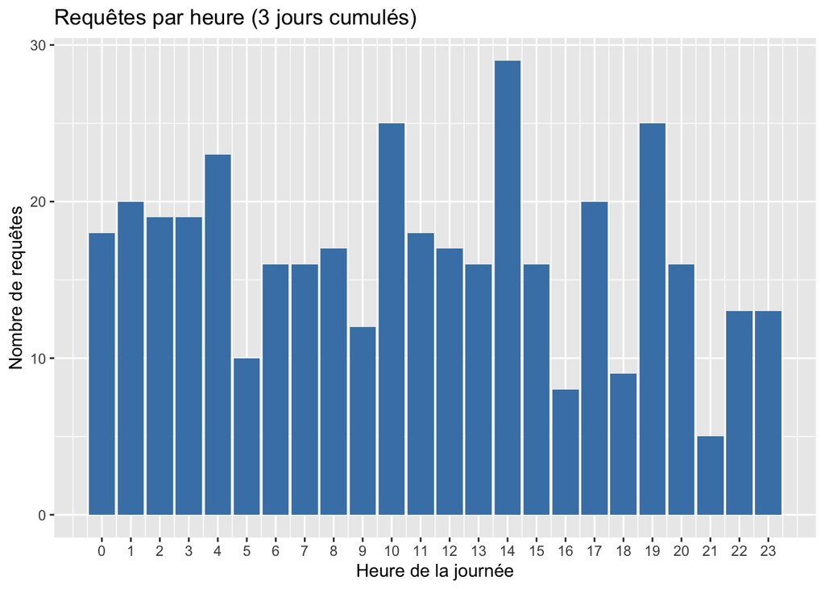

```r
ggplot(par_heure, aes(x = heure, y = n)) +
  geom_col(fill = "steelblue") +
  scale_x_continuous(breaks = 0:23) +
  labs(x = "Heure de la journée", y = "Nombre de requêtes",
       title = "Requêtes par heure (3 jours cumulés)")
```

**Réponse :** tous jours confondus, le serveur est le plus sollicité à 14 h avec 29 requêtes (contre 16.7 en moyenne par heure).

### c. Utilisateurs avec le plus d’erreurs, part des requêtes anonymes

```r
erreurs_user <- log |>
  filter(niveau == "ERROR") |>
  count(user, sort = TRUE)
erreurs_user |> slice_head(n = 5)
```

```
## # A tibble: 5 × 2
##   user         n
##   <chr>    <int>
## 1 jade         5
## 2 rokhaya      4
## 3 valerie      4
## 4 awa          3
## 5 clemence     3
```

```r
part_anonyme <- mean(is.na(log$user))
part_anonyme
```

```
## [1] 0.0425
```

**Réponse :** les utilisateurs ayant le plus d’erreurs sont jade (5), rokhaya (4), valerie (4). Les requêtes anonymes (`user=-`) représentent 17 requêtes sur 400, soit 4.2 %.

## C4

### a. Durée médiane et 90<sup>e</sup> centile par action

```r
durees_action <- log |>
  group_by(action) |>
  summarise(n = n(),
            mediane = median(duree),
            centile_90 = quantile(duree, 0.9)) |>
  arrange(desc(mediane))
durees_action
```

```
## # A tibble: 6 × 4
##   action       n mediane centile_90
##   <chr>    <int>   <dbl>      <dbl>
## 1 upload      17    257        536
## 2 login       77    222        533.
## 3 logout      61    207        614
## 4 download    81    199        796
## 5 search      74    194        514.
## 6 view        90    180.       622.
```

**Réponse :** l’action la plus lente est upload (médiane 257 ms, 90<sup>e</sup> centile 536 ms), la plus rapide view (médiane 180.5 ms). Le 90<sup>e</sup> centile signifie que 10 % des requêtes de chaque action durent plus longtemps que cette valeur.

### b. Durée médiane par niveau

```r
durees_niveau <- log |>
  group_by(niveau) |>
  summarise(n = n(), mediane = median(duree), moyenne = mean(duree))
durees_niveau
```

```
## # A tibble: 3 × 4
##   niveau     n mediane moyenne
##   <chr>  <int>   <dbl>   <dbl>
## 1 ERROR     38     785   1124.
## 2 INFO     317     176    230.
## 3 WARN      45     196    241.
```

**Réponse :** oui, la durée médiane des requêtes en erreur est de 785 ms contre 176 ms pour les requêtes INFO, soit 4.5 fois plus. C’est cohérent avec les messages d’erreur (délais d’attente, mémoire insuffisante) : une requête qui échoue a souvent attendu longtemps avant d’échouer.

### c. Messages d’erreur

```r
messages <- log |>
  filter(!is.na(msg)) |>
  count(niveau, msg, sort = TRUE)
messages
```

```
## # A tibble: 4 × 3
##   niveau msg                         n
##   <chr>  <chr>                   <int>
## 1 ERROR  Timeout base de données    12
## 2 ERROR  Connexion refusée          10
## 3 ERROR  Mémoire insuffisante        9
## 4 ERROR  Fichier introuvable         7
```

**Réponse :** on trouve 4 messages différents : « Timeout base de données » (12), « Connexion refusée » (10), « Mémoire insuffisante » (9), « Fichier introuvable » (7). Ils apparaissent sur 38 lignes, toutes de niveau ERROR.

### d. Fichiers téléchargés avec succès, par extension

```r
telechargements <- log |>
  filter(action == "download", code == 200) |>
  mutate(extension = str_extract(fichier, "(?<=\\.)[[:alnum:]]+$"))

telechargements |> count(fichier, sort = TRUE)
```

```
## # A tibble: 6 × 2
##   fichier              n
##   <chr>            <int>
## 1 photo.png           14
## 2 data.csv            12
## 3 cours_R.html        10
## 4 rapport_2025.pdf     8
## 5 archive.zip          7
## 6 notes.xlsx           7
```

```r
par_extension <- telechargements |> count(extension, sort = TRUE)
par_extension
```

```
## # A tibble: 6 × 2
##   extension     n
##   <chr>     <int>
## 1 png          14
## 2 csv          12
## 3 html         10
## 4 pdf           8
## 5 xlsx          7
## 6 zip           7
```

**Réponse :** 58 téléchargements ont réussi. Le fichier le plus téléchargé est photo.png (14 fois). Par extension : png (14), csv (12), html (10), pdf (8), xlsx (7), zip (7).

## C5

### a. Requêtes venant de l’extérieur

Les points de `192.168.` doivent être échappés, et le motif ancré au début : sans ancre, une adresse comme `10.192.168.1` serait considérée comme interne.

```r
log <- log |>
  mutate(externe = !str_detect(ip, "^192\\.168\\."))

n_externes <- sum(log$externe)
n_ip_externes <- n_distinct(log$ip[log$externe])
n_externes
```

```
## [1] 25
```

```r
n_ip_externes
```

```
## [1] 2
```

**Réponse :** 25 requêtes sur 400 (6.2 %) viennent de l’extérieur du réseau interne, depuis 2 adresses distinctes (203.0.113.42 et 203.0.113.7).

### b. Profil des adresses extérieures

```r
ip_externes <- log |>
  filter(externe) |>
  group_by(ip) |>
  summarise(requetes     = n(),
            utilisateurs = n_distinct(user, na.rm = TRUE),
            erreurs      = sum(niveau == "ERROR"),
            refus        = sum(code %in% c(401, 429)),
            nuit         = sum(hour(horodatage) < 7)) |>
  arrange(desc(utilisateurs))
ip_externes
```

```
## # A tibble: 2 × 6
##   ip           requetes utilisateurs erreurs refus  nuit
##   <chr>           <int>        <int>   <int> <int> <int>
## 1 203.0.113.7        20           10       0     0     7
## 2 203.0.113.42        5            5       0     0     2
```

```r
# Liste des comptes utilisés depuis chaque adresse
log |>
  filter(externe) |>
  group_by(ip) |>
  summarise(comptes = str_c(sort(unique(user)), collapse = ", ")) |>
  as.data.frame()
```

```
##             ip
## 1 203.0.113.42
## 2  203.0.113.7
##                                                                comptes
## 1                                  awa, chen, moussa, pauline, quentin
## 2 awa, chen, clemence, dina, elias, gael, jade, rokhaya, sami, valerie
```

**Réponse :** les adresses extérieures ne produisent **aucune** erreur ni aucun refus, donc ce n’est pas ce critère qui les distingue. La plus suspecte est **203.0.113.7** : 20 requêtes réparties entre **10 comptes différents**, dont 7 entre minuit et 7 h. Une même adresse extérieure qui se connecte avec autant de comptes, sans jamais échouer, évoque des identifiants volés ou partagés plutôt qu’un utilisateur légitime en télétravail (qui utiliserait un seul compte). L’absence de refus est même inquiétante : les mots de passe utilisés sont tous valides. L’autre adresse, 203.0.113.42, mérite aussi d’être surveillée : ses 5 requêtes utilisent 5 comptes différents, mais son volume est bien plus faible.

### c. Format IPv4

```r
motif_ipv4 <- "^\\d{1,3}\\.\\d{1,3}\\.\\d{1,3}\\.\\d{1,3}$"
ip_ok <- str_detect(log$ip, motif_ipv4)
all(ip_ok)
```

```
## [1] TRUE
```

```r
log$ip[!ip_ok]
```

```
## character(0)
```

**Réponse :** **toutes** les 400 adresses ont bien la forme d’une adresse IPv4. Cette regex ne vérifie que la forme : elle accepterait par exemple `999.1.1.1`, alors que chaque nombre d’une vraie adresse IPv4 est compris entre 0 et 255.

# Partie D : Analyse textuelle d’avis clients

## D1

### a. Import et longueur des avis

```r
avis <- read_csv("data/avis_clients.csv", show_col_types = FALSE)
glimpse(avis)
```

```
## Rows: 180
## Columns: 5
## $ id_avis <dbl> 1, 2, 3, 4, 5, 6, 7, 8, 9, 10, 11, 12, 13, 14, 15, 16, 17, 18,…
## $ date    <date> 2025-03-01, 2025-03-03, 2025-03-06, 2025-03-08, 2025-03-11, 2…
## $ produit <chr> "Veste pluie légère", "Gourde isotherme", "Raquette junior", "…
## $ note    <dbl> 1, 5, 5, 2, 5, 5, 1, 5, 4, 5, 1, 2, 4, 2, 4, 4, 2, 4, 4, 5, 4,…
## $ texte   <chr> "Trop cher pour ce que c'est", "Je recommande et excellent rap…
```

```r
avis <- avis |>
  mutate(longueur = str_length(texte))

summary(avis$longueur)
```

```
##    Min. 1st Qu.  Median    Mean 3rd Qu.    Max.
##    4.00   28.00   44.00   42.62   58.00   81.00
```

```r
avis_long <- avis |> slice_max(longueur, n = 1)
avis_long |> select(id_avis, produit, note, longueur, texte) |> as.data.frame()
```

```
##   id_avis             produit note longueur
## 1      71 Chaussures trail X3    5       81
##                                                                               texte
## 1 EXCELLENT RAPPORT QUALITÉ/PRIX ! TRÈS SATISFAIT ! CONFORTABLE DÈS LE PREMIER JOUR
```

**Réponse :** le fichier contient 180 avis sur 6 produits. Un avis fait en moyenne 42.6 caractères (médiane 44, de 4 à 81). L’avis le plus long (n° 71, Chaussures trail X3, note 5) compte 81 caractères : « EXCELLENT RAPPORT QUALITÉ/PRIX ! TRÈS SATISFAIT ! CONFORTABLE DÈS LE PREMIER JOUR ».

### b. Avis entièrement en majuscules

Un avis est « entièrement en majuscules » s’il contient au moins une lettre (`[[:alpha:]]`) et **aucune** minuscule (`[[:lower:]]`, accents compris). Le premier test évite de compter un avis qui ne serait fait que de ponctuation ou d’émoticônes.

```r
avis <- avis |>
  mutate(majuscules = str_detect(texte, "[[:alpha:]]") & !str_detect(texte, "[[:lower:]]"))

avis |> filter(majuscules) |> select(id_avis, note, texte) |> as.data.frame()
```

```
##    id_avis note
## 1        7    1
## 2       21    4
## 3       49    4
## 4       68    3
## 5       69    4
## 6       71    5
## 7       75    4
## 8       98    4
## 9      104    3
## 10     109    3
## 11     126    5
## 12     140    5
## 13     146    5
## 14     149    3
```

[output cut: 19 more lines]

```r
notes_majuscules <- avis |>
  group_by(majuscules) |>
  summarise(n = n(), note_moyenne = mean(note), note_mediane = median(note))
notes_majuscules
```

```
## # A tibble: 2 × 4
##   majuscules     n note_moyenne note_mediane
##   <lgl>      <int>        <dbl>        <dbl>
## 1 FALSE        164         3.85            4
## 2 TRUE          16         3.94            4
```

**Réponse :** 16 avis sont écrits entièrement en majuscules. Leur note moyenne est de 3.94 contre 3.85 pour les autres : l’écart (0.09 point) est faible. Contrairement à l’intuition (« crier » pour se plaindre), écrire en majuscules n’est pas ici le signe d’un avis négatif : 11 de ces 16 avis ont d’ailleurs une note de 4 ou 5 (« SUPER PRODUIT », « JE RECOMMANDE »).

### c. Points d’exclamation et émoticônes

`!` n’est pas un métacaractère, mais `)` et `(` le sont : on cherche les émoticônes avec `fixed()` (texte exact) plutôt qu’avec une regex.

```r
avis <- avis |>
  mutate(exclamation = str_detect(texte, fixed("!")),
         smiley      = str_detect(texte, fixed(":)")),
         frowny      = str_detect(texte, fixed(":(")))

n_exclamation <- sum(avis$exclamation)
n_smiley <- sum(avis$smiley)
n_frowny <- sum(avis$frowny)
n_emoticone <- sum(avis$smiley | avis$frowny)
c(exclamation = n_exclamation, `:)` = n_smiley, `:(` = n_frowny, emoticone = n_emoticone)
```

```
## exclamation          :)          :(   emoticone
##          38           7           7          14
```

```r
# Nombre total de « ! » (certains avis en contiennent plusieurs : « !!! »)
sum(str_count(avis$texte, fixed("!")))
```

```
## [1] 83
```

**Réponse :** 38 avis (21 %) contiennent au moins un point d’exclamation, pour un total de 83 « ! ». 14 avis contiennent une émoticône : 7 avec `:)` et 7 avec `:(`.

## D2

### a. Une ligne par mot

`str_split()` renvoie une liste (un vecteur de mots par avis) ; `unnest()` la « déplie » en une ligne par mot, en recopiant `id_avis`, `produit` et `note`. Le motif `[^[:alpha:]']+` désigne une suite de caractères qui ne sont ni des lettres (accents compris) ni des apostrophes : on garde ainsi « c’est » ou « d’un » en un seul mot. Un avis qui se termine par une ponctuation produit une chaîne vide en fin de découpage, d’où le filtre.

```r
mots <- avis |>
  select(id_avis, produit, note, texte) |>
  mutate(mot = str_split(str_to_lower(texte), "[^[:alpha:]']+")) |>
  unnest(mot) |>
  filter(mot != "") |>
  select(-texte)
mots
```

```
## # A tibble: 1,169 × 4
##    id_avis produit             note mot
##      <dbl> <chr>              <dbl> <chr>
##  1       1 Veste pluie légère     1 trop
##  2       1 Veste pluie légère     1 cher
##  3       1 Veste pluie légère     1 pour
##  4       1 Veste pluie légère     1 ce
##  5       1 Veste pluie légère     1 que
##  6       1 Veste pluie légère     1 c'est
##  7       2 Gourde isotherme       5 je
##  8       2 Gourde isotherme       5 recommande
##  9       2 Gourde isotherme       5 et
## 10       2 Gourde isotherme       5 excellent
## # ℹ 1,159 more rows
```

### b. Nombre de mots

```r
n_mots <- nrow(mots)
n_mots_distincts <- n_distinct(mots$mot)
n_mots
```

```
## [1] 1169
```

```r
n_mots_distincts
```

```
## [1] 64
```

**Réponse :** les 180 avis totalisent 1169 mots, soit 6.5 mots par avis en moyenne, mais seulement 64 mots distincts : les avis réutilisent toujours les mêmes formules (« livraison rapide », « je recommande »…).

### c. Mots les plus fréquents

```r
top_mots <- mots |> count(mot, sort = TRUE) |> slice_head(n = 10)
top_mots
```

```
## # A tibble: 10 × 2
##    mot            n
##    <chr>      <int>
##  1 et            72
##  2 qualité       54
##  3 la            53
##  4 satisfait     38
##  5 très          38
##  6 le            37
##  7 livraison     37
##  8 je            36
##  9 recommande    36
## 10 pour          34
```

Les mots les plus fréquents sont surtout des « mots outils » sans contenu. On définit un vecteur de mots vides (articles, prépositions, pronoms, conjonctions, auxiliaires) et on les retire :

```r
mots_vides <- c("le", "la", "les", "l'", "un", "une", "des", "du", "de", "d'un", "d'une",
                "au", "aux", "à", "en", "dans", "pour", "par", "sur", "avec", "dès",
                "et", "ou", "mais", "ce", "c'est", "que", "qui", "je", "j'", "il", "elle",
                "on", "se", "s'est", "est", "ne", "pas", "très", "trop", "peu", "tout",
                "rien", "fait", "bout")

mots_pleins <- mots |> filter(!mot %in% mots_vides)

top_mots_pleins <- mots_pleins |> count(mot, sort = TRUE) |> slice_head(n = 10)
top_mots_pleins
```

```
## # A tibble: 10 × 2
##    mot            n
##    <chr>      <int>
##  1 qualité       54
##  2 satisfait     38
##  3 livraison     37
##  4 recommande    36
##  5 conforme      32
##  6 rapide        30
##  7 produit       29
##  8 super         29
##  9 bonne         28
## 10 parfait       28
```

**Réponse :** sans filtre, les 10 mots les plus fréquents sont « et » (72), « qualité » (54), « la » (53), « satisfait » (38), « très » (38), « le » (37), « livraison » (37), « je » (36), « recommande » (36), « pour » (34) : on y trouve surtout des mots outils (« et », « la », « le », « je », « pour »). Une fois les 45 mots vides retirés (il en reste 705 occurrences), le top 10 devient « qualité » (54), « satisfait » (38), « livraison » (37), « recommande » (36), « conforme » (32), « rapide » (30), « produit » (29), « super » (29), « bonne » (28), « parfait » (28), ce qui décrit bien mieux le contenu des avis : qualité, livraison, satisfaction. J’ai aussi classé « très », « trop » ou « pas » parmi les mots vides pour ce comptage, mais ce choix se discute : « pas » et « trop » portent une information (négation, excès) utile pour le sentiment.

## D3

### a. Mots fréquents par catégorie d’avis

```r
categorie_note <- function(note) {
  case_when(note <= 2 ~ "négatif",
            note == 3 ~ "neutre",
            note >= 4 ~ "positif")
}

avis <- avis |> mutate(categorie = categorie_note(note))
mots_pleins <- mots_pleins |> mutate(categorie = categorie_note(note))

avis |> count(categorie)
```

```
## # A tibble: 3 × 2
##   categorie     n
##   <chr>     <int>
## 1 neutre       27
## 2 négatif      27
## 3 positif     126
```

```r
top_categorie <- mots_pleins |>
  count(categorie, mot) |>
  group_by(categorie) |>
  slice_max(n, n = 5, with_ties = FALSE) |>
  ungroup()
top_categorie
```

```
## # A tibble: 15 × 3
##    categorie mot                n
##    <chr>     <chr>          <int>
##  1 neutre    travail           11
##  2 neutre    lourd             10
##  3 neutre    correct            9
##  4 neutre    conforme           7
##  5 neutre    d'exceptionnel     5
##  6 négatif   recommande         9
##  7 négatif   petite             8
##  8 négatif   taille             8
##  9 négatif   cassé              7
## 10 négatif   livraison          7
## 11 positif   qualité           50
## 12 positif   satisfait         38
## 13 positif   bonne             28
## 14 positif   parfait           28
## 15 positif   randonnée         28
```

```r
# Même résultat présenté sur une ligne par catégorie
top_categorie_txt <- top_categorie |>
  group_by(categorie) |>
  summarise(top5 = str_c(mot, " (", n, ")", collapse = ", "))
top_categorie_txt |> as.data.frame()
```

```
##   categorie
## 1    neutre
## 2   négatif
## 3   positif
##                                                                      top5
## 1 travail (11), lourd (10), correct (9), conforme (7), d'exceptionnel (5)
## 2        recommande (9), petite (8), taille (8), cassé (7), livraison (7)
## 3  qualité (50), satisfait (38), bonne (28), parfait (28), randonnée (28)
```

**Réponse :**

- avis **négatifs** (27 avis) : recommande (9), petite (8), taille (8), cassé (7), livraison (7) ;
- avis **neutres** (27 avis) : travail (11), lourd (10), correct (9), conforme (7), d’exceptionnel (5) ;
- avis **positifs** (126 avis) : qualité (50), satisfait (38), bonne (28), parfait (28), randonnée (28).

Les avis négatifs parlent de taille trop petite, de produits cassés et de livraison (en retard), les avis neutres de produits « corrects » qui « font le travail », les avis positifs de qualité et de satisfaction. On remarque que « recommande » apparaît dans les avis négatifs, à cause de la tournure « je **ne** recommande **pas** » : compter les mots isolés perd la négation (voir D4).

### b. Note moyenne des avis contenant chaque mot

On ne compte un mot qu’**une fois par avis** (`distinct()`), pour que la moyenne porte sur des avis et non sur des occurrences (un avis qui répète « rapide » ne doit pas peser deux fois).

```r
note_par_mot <- mots_pleins |>
  add_count(mot, name = "occurrences") |>
  filter(occurrences >= 10) |>
  distinct(id_avis, mot, note, occurrences) |>
  group_by(mot) |>
  summarise(occurrences = first(occurrences),
            n_avis = n(),
            note_moyenne = mean(note)) |>
  arrange(desc(note_moyenne))

note_par_mot |> as.data.frame()
```

```
##            mot occurrences n_avis note_moyenne
## 1        léger          21     21     4.714286
## 2       solide          21     21     4.714286
## 3    satisfait          38     38     4.657895
## 4        bonne          28     28     4.642857
## 5      parfait          28     28     4.607143
## 6    randonnée          28     28     4.607143
## 7  description          25     25     4.560000
## 8      produit          29     29     4.482759
## 9        super          29     29     4.482759
## 10   excellent          23     23     4.478261
## 11        prix          23     23     4.478261
## 12     rapport          23     23     4.478261
## 13     qualité          54     49     4.408163
## 14 confortable          26     26     4.384615
## 15        jour          26     26     4.384615
## 16     premier          26     26     4.384615
## 17      rapide          30     30     4.333333
## 18    conforme          32     32     4.218750
## 19  recommande          36     36     3.944444
## 20   livraison          37     37     3.756757
## 21       lourd          10     10     3.000000
## 22     travail          11     11     3.000000
## 23      petite          11     11     1.818182
## 24      taille          11     11     1.818182
```

**Réponse :** parmi les 24 mots qui apparaissent au moins 10 fois (hors mots vides), ceux associés aux **meilleures** notes sont « léger » (4.71), « solide » (4.71), « satisfait » (4.66), et ceux associés aux **pires** notes sont « taille » (1.82), « petite » (1.82), « travail » (3). La note moyenne de l’ensemble des avis étant de 3.86, un mot nettement en dessous est un bon indicateur de mécontentement.

## D4

```r
lex_positif <- c("satisfait", "excellent", "rapide", "confortable", "recommande", "parfait",
                 "solide", "léger", "super", "bonne", "conforme", "correct")
lex_negatif <- c("déçu", "petite", "retard", "cassé", "étanche", "injoignable", "cher",
                 "fragile", "mauvaise", "lourd")
```

### a. Score de sentiment

Règle pour la négation : on passe le texte en minuscules (pour traiter aussi « JE NE RECOMMANDE PAS »), puis on remplace « ne recommande pas » par « déconseille », mot qui n’est pas dans le lexique positif. Plus généralement, on remplace toute forme « ne *mot* pas » par « ne_*mot* » (par exemple « ne_recommande ») : le mot ainsi transformé n’est plus reconnu comme positif, quel que soit le verbe nié.

Pour compter, on construit un motif `\\b(mot1|mot2|…)\\b` avec `str_c(collapse = "|")` : les frontières de mot `\\b` empêchent de compter « léger » dans « légère » ou « super » dans « superbe ». `str_count()` compte alors, pour chaque avis, toutes les occurrences en une seule instruction (sans boucle).

```r
motif_positif <- str_c("\\b(", str_c(lex_positif, collapse = "|"), ")\\b")
motif_negatif <- str_c("\\b(", str_c(lex_negatif, collapse = "|"), ")\\b")
motif_positif
```

```
## [1] "\\b(satisfait|excellent|rapide|confortable|recommande|parfait|solide|léger|super|bonne|conforme|correct)\\b"
```

```r
avis <- avis |>
  mutate(
    texte_min = texte |>
      str_to_lower() |>
      str_replace_all("\\bne recommande pas\\b", "déconseille") |>
      str_replace_all("\\bne (\\w+) pas\\b", "ne_\\1"),
    positifs = str_count(texte_min, motif_positif),
    negatifs = str_count(texte_min, motif_negatif),
    score    = positifs - negatifs
  )

# Vérification sur les avis contenant une négation
avis |>
  filter(str_detect(texte_min, "déconseille|ne_")) |>
  select(id_avis, note, texte_min, positifs, negatifs, score) |>
  as.data.frame()
```

```
##   id_avis note
## 1       7    1
## 2      12    2
## 3      14    2
## 4      17    2
## 5      31    1
## 6      38    2
## 7      52    1
## 8     105    1
## 9     137    1
##                                                                   texte_min
## 1                                    taille trop petite ! je déconseille...
## 2         je déconseille. taille trop petite. s'est cassé au bout d'un mois
## 3 service client injoignable. je déconseille. s'est cassé au bout d'un mois
## 4          trop cher pour ce que c'est. je déconseille. livraison en retard
## 5         fermeture éclair fragile et pas étanche du tout et je déconseille
## 6                                          je déconseille. mauvaise qualité
## 7          livraison en retard et pas étanche du tout et je déconseille !!!
## 8                           trop cher pour ce que c'est, je déconseille !!!
## 9                                                 je déconseille et déçu :(
##   positifs negatifs score
## 1        0        1    -1
## 2        0        2    -2
## 3        0        2    -2
## 4        0        2    -2
## 5        0        2    -2
## 6        0        1    -1
## 7        0        2    -2
## 8        0        1    -1
## 9        0        1    -1
```

```r
avis |> count(score)
```

```
## # A tibble: 8 × 2
##   score     n
##   <int> <int>
## 1    -3     4
## 2    -2    11
## 3    -1    18
## 4     0    10
## 5     1    42
## 6     2    40
## 7     3    40
## 8     4    15
```

**Réponse :** 9 avis contiennent « ne recommande pas » ; sans la règle, chacun aurait gagné un mot positif à tort. Les scores vont de -3 à 4, avec 137 avis de score positif, 10 de score nul et 33 de score négatif.

### b. Corrélation entre le score et la note

```r
correlation <- cor(avis$score, avis$note)
correlation
```

```
## [1] 0.8205517
```

```r
avis |>
  group_by(note) |>
  summarise(n = n(), score_moyen = mean(score))
```

```
## # A tibble: 5 × 3
##    note     n score_moyen
##   <dbl> <int>       <dbl>
## 1     1    16      -1.69
## 2     2    11      -1.64
## 3     3    27       0.259
## 4     4    55       2
## 5     5    71       2.51
```

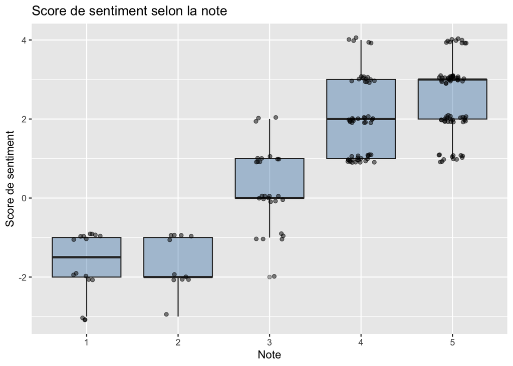

```r
ggplot(avis, aes(x = factor(note), y = score)) +
  geom_boxplot(fill = "steelblue", alpha = 0.4) +
  geom_jitter(width = 0.15, height = 0.1, alpha = 0.5) +
  labs(x = "Note", y = "Score de sentiment",
       title = "Score de sentiment selon la note")
```

**Réponse :** la corrélation entre le score et la note vaut 0.82 (elle serait de 0.8 sans la règle de négation). C’est une corrélation forte : le score moyen croît bien avec la note, ce qui en fait un indicateur plutôt bon vu la simplicité de la méthode (deux lexiques de 10 à 12 mots). Il reste cependant imparfait : les avis neutres (note 3) ont des scores allant de -2 à 2, car ils emploient peu de mots des lexiques (« fait le travail », « rien d’exceptionnel » donnent 0) ou mélangent mots positifs et négatifs (« conforme… un peu lourd ») ; le score distingue aussi mal une note 4 d’une note 5 (score moyen 2 contre 2.51). Enfin, la méthode ignore l’ironie, les émoticônes et les négations autres que celles traitées.

### c. Contradictions entre score et note

```r
contradictions <- avis |>
  filter((score > 0 & note <= 2) | (score < 0 & note >= 4)) |>
  select(id_avis, note, score, texte)
contradictions |> as.data.frame()
```

```
## [1] id_avis note    score   texte
## <0 rows> (or 0-length row.names)
```

```r
avis_frowny <- avis |>
  filter(frowny) |>
  select(id_avis, note, positifs, negatifs, score, texte)
avis_frowny |> as.data.frame()
```

```
##   id_avis note positifs negatifs score
## 1       5    5        3        0     3
## 2      58    4        2        0     2
## 3      84    5        4        0     4
## 4      98    4        1        0     1
## 5     137    1        0        1    -1
## 6     164    4        2        0     2
## 7     177    5        2        0     2
##                                                         texte
## 1 Très satisfait. conforme à la description. je recommande :(
## 2        Excellent rapport qualité/prix ! livraison rapide :(
## 3          Super produit ! je recommande ! solide et léger :(
## 4                                            JE RECOMMANDE :(
## 5                             Je ne recommande pas et déçu :(
## 6         Confortable dès le premier jour ! très satisfait :(
## 7                       LIVRAISON RAPIDE ET TRÈS SATISFAIT :(
```

**Réponse :** **aucun** avis ne présente de contradiction entre le score et la note : tous les avis notés 1 ou 2 ont un score négatif, et tous les avis notés 4 ou 5 un score positif. Les 10 avis de score nul sont tous notés 3. Avec la règle de négation, le score ne se trompe donc jamais de « sens » ; ses imprécisions portent sur les avis neutres (voir b).

Parmi les 7 avis contenant l’émoticône `:(`, 6 ont une note de 4 ou 5 et 6 un score positif (note moyenne 4, score moyen 1.86). On constate que l’émoticône triste est en contradiction avec le texte (« je recommande :( », « très satisfait :( ») : elle est sans doute utilisée par erreur ou de façon ironique, ou ces avis ont été mal saisis. Ni le score (qui ignore les émoticônes) ni la note ne la reflètent : se fier à `:(` pour repérer les avis négatifs serait donc trompeur, et il vaut mieux ne pas l’ajouter au lexique négatif.

## D5

Le mot négatif le plus cité est cherché dans les textes après traitement de la négation (`texte_min`), avec `str_extract_all()` qui renvoie la liste des mots négatifs de chaque avis. En cas d’égalité, on garde tous les mots ex æquo.

```r
mot_negatif_produit <- avis |>
  select(produit, texte_min) |>
  mutate(mot = str_extract_all(texte_min, motif_negatif)) |>
  unnest(mot) |>
  count(produit, mot) |>
  group_by(produit) |>
  filter(n == max(n)) |>
  summarise(mot_negatif = str_c(mot, collapse = " / "),
            n_mot_negatif = first(n))

synthese <- avis |>
  group_by(produit) |>
  summarise(n_avis       = n(),
            note_moyenne = mean(note),
            score_moyen  = mean(score),
            part_negatifs = mean(note <= 2)) |>
  left_join(mot_negatif_produit, by = "produit") |>
  arrange(note_moyenne)

synthese |>
  mutate(note_moyenne  = round(note_moyenne, 2),
         score_moyen   = round(score_moyen, 2),
         part_negatifs = str_c(round(100 * part_negatifs), " %")) |>
  as.data.frame()
```

```
##               produit n_avis note_moyenne score_moyen part_negatifs mot_negatif
## 1  Veste pluie légère     34         3.56        1.32          18 %       lourd
## 2      Sac à dos 30 L     29         3.69        0.69          17 %       lourd
## 3    Gourde isotherme     30         3.83        1.20          17 %      petite
## 4 Chaussures trail X3     34         3.97        1.50          12 %      petite
## 5     Raquette junior     27         4.00        1.74          19 %      petite
## 6      Tente 2 places     26         4.15        1.96           8 %        cher
##   n_mot_negatif
## 1             3
## 2             4
## 3             3
## 4             3
## 5             2
## 6             2
```

**Conclusion pour le responsable produit :** le produit le moins bien noté est « **Veste pluie légère** » (note moyenne de 3.56/5 sur 34 avis, 18 % d’avis négatifs), et le mot négatif qui revient le plus dans ses avis est « lourd » (3 fois) : c’est le premier point à corriger. À l’inverse, « **Tente 2 places** » est le produit le mieux noté (4.15/5, score de sentiment moyen de 1.96, 8 % d’avis négatifs), même si quelques clients lui reprochent d’être « cher ».